# Análisis de la toma de decisión en Tiros en la Bundesliga 2023/24

# 4 Métricas geométricas de tiro

En esta sección se implementan, paso a paso, las métricas espaciales para que queden guardadas en el DataFrame:

- Distancia del disparo al centro de la portería (`distancia_centro_porteria`).
- Ángulo de tiro con la portería (`angulo_porteria`).
- Rivales dentro del ángulo balón-portería (`rivales_en_angulo` y `num_rivales_angulo`).
- Distancia al rival más cercano dentro de ese ángulo (`distancia_rival_mas_cercano`).

## 4.1 Paso 1. Distancia del disparo al centro de la portería

**Mostrar código**

```python
shots_360_limpio['distancia_centro_porteria'] = shots_360_limpio.apply(
  lambda row: ((120 - row['x'])**2 + (40 - row['y'])**2)**0.5,
  axis=1,
)

shots_360_limpio[['x', 'y', 'distancia_centro_porteria']].head()
```

|  | x | y | distancia_centro_porteria |
| --- | --- | --- | --- |
| 1 | 114.6 | 33.5 | 8.450444 |
| 3 | 113.9 | 47.4 | 9.590099 |
| 4 | 89.2 | 42.5 | 30.901294 |
| 5 | 110.2 | 32.6 | 12.280065 |
| 7 | 108.0 | 40.0 | 12.000000 |

## 4.2 Paso 2. Ángulo con la portería

**Mostrar código**

```python
shots_360_limpio['angulo_porteria'] = shots_360_limpio.apply(
  lambda row: np.degrees(
    np.arccos(

      np.clip(
        (
          (120 - row['x'])**2 + (36 - row['y']) * (44 - row['y'])
        )
        /
        (
          ((120 - row['x'])**2 + (36 - row['y'])**2)**0.5
          *
          ((120 - row['x'])**2 + (44 - row['y'])**2)**0.5
        ),
        -1.0,
        1.0,
      )
    )
  ),
  axis=1,
)

shots_360_limpio[['x', 'y', 'angulo_porteria']].head()
```

|  | x | y | angulo_porteria |
| --- | --- | --- | --- |
| 1 | 114.6 | 33.5 | 37.941499 |
| 3 | 113.9 | 47.4 | 32.715019 |
| 4 | 89.2 | 42.5 | 14.704957 |
| 5 | 110.2 | 32.6 | 30.182384 |
| 7 | 108.0 | 40.0 | 36.869898 |

## 4.3 Paso 3. Jugadores en el ángulo balón-portería

**Mostrar código**

```python
POSTE_1 = (120, 36)
POSTE_2 = (120, 44)


def punto_en_triangulo(x_player, y_player, x_ball, y_ball):
  # El jugador debe estar por delante del balón
  if x_player <= x_ball:
    return False

  xA, yA = x_ball, y_ball
  xB, yB = POSTE_1
  xC, yC = POSTE_2
  xP, yP = x_player, y_player

  delta = (yB - yC) * (xA - xC) + (xC - xB) * (yA - yC)
  if delta == 0:
    return False


  w1 = ((yB - yC) * (xP - xC) + (xC - xB) * (yP - yC)) / delta
  w2 = ((yC - yA) * (xP - xC) + (xA - xC) * (yP - yC)) / delta

  return w1 >= 0 and w2 >= 0 and (w1 + w2) <= 1


def procesar_jugadores_y_angulo(row, columna_jugadores):
  x_ball, y_ball = row['x'], row['y']
  lista_original = row[columna_jugadores] if isinstance(row[columna_jugadores], list) else []
  nueva_lista_tripletas = []

  for jugador in lista_original:
    x_jugador = jugador.get('x', np.nan)
    y_jugador = jugador.get('y', np.nan)

    if pd.isna(x_jugador) or pd.isna(y_jugador):
      continue

    is_blocking = punto_en_triangulo(x_jugador, y_jugador, x_ball, y_ball)
    nueva_lista_tripletas.append((x_jugador, y_jugador, is_blocking))

  return nueva_lista_tripletas


shots_360_limpio['rivales_en_angulo'] = shots_360_limpio.apply(
  lambda row: procesar_jugadores_y_angulo(row, 'posiciones_rivales'),
  axis=1,
)

shots_360_limpio['companeros_en_angulo'] = shots_360_limpio.apply(
  lambda row: procesar_jugadores_y_angulo(row, 'posiciones_compañeros'),
  axis=1,
)

shots_360_limpio['num_rivales_angulo'] = shots_360_limpio['rivales_en_angulo'].apply(
  lambda lista: sum(1 for _, _, is_blocking in lista if is_blocking)
)

shots_360_limpio['num_companeros_angulo'] = shots_360_limpio['companeros_en_angulo'].apply(
  lambda lista: sum(1 for _, _, is_blocking in lista if is_blocking)
)

shots_360_limpio['num_jugadores_angulo'] = (
  shots_360_limpio['num_rivales_angulo'] + shots_360_limpio['num_companeros_angulo']
)

shots_360_limpio[['num_rivales_angulo', 'num_companeros_angulo', 'num_jugadores_angulo']].head()
```

|  | num_rivales_angulo | num_companeros_angulo | num_jugadores_angulo |
| --- | --- | --- | --- |
| 1 | 1 | 0 | 1 |
| 3 | 1 | 0 | 1 |
| 4 | 3 | 0 | 3 |
| 5 | 2 | 0 | 2 |
| 7 | 0 | 0 | 0 |

## 4.4 Paso 4. Distancia al rival más cercano dentro del ángulo

**Mostrar código**

```python
def distancia_al_jugador_mas_cercano(row, columna_jugadores):
  x_ball, y_ball = row['x'], row['y']
  lista_jugadores = row[columna_jugadores] if isinstance(row[columna_jugadores], list) else []
  distancias = []

  for x_jugador, y_jugador, is_blocking in lista_jugadores:
    if is_blocking:
      distancia = ((x_jugador - x_ball)**2 + (y_jugador - y_ball)**2)**0.5
      distancias.append(distancia)

  return min(distancias) if distancias else np.nan


shots_360_limpio['distancia_rival_mas_cercano'] = shots_360_limpio.apply(
  lambda row: distancia_al_jugador_mas_cercano(row, 'rivales_en_angulo'),
  axis=1,
)

shots_360_limpio[['num_rivales_angulo', 'distancia_rival_mas_cercano']].head()
```

|  | num_rivales_angulo | distancia_rival_mas_cercano |
| --- | --- | --- |
| 1 | 1 | 4.701064 |
| 3 | 1 | 7.433034 |
| 4 | 3 | 12.847179 |
| 5 | 2 | 7.657676 |
| 7 | 0 | NaN |

## 4.5 Paso 5. Comprobación final de columnas guardadas

**Mostrar código**

```python
columnas_metricas = [
  'distancia_centro_porteria',
  'angulo_porteria',
  'num_rivales_angulo',
  'num_companeros_angulo',
  'num_jugadores_angulo',
  'distancia_rival_mas_cercano',
]

shots_360_limpio[columnas_metricas].head()

# Si prefieres usar el nombre original del DataFrame en celdas posteriores:
all_shots_360 = shots_360_limpio.copy()
```

## 4.6 Campograma de ejemplo con ángulo y rivales bloqueando

**Mostrar código**

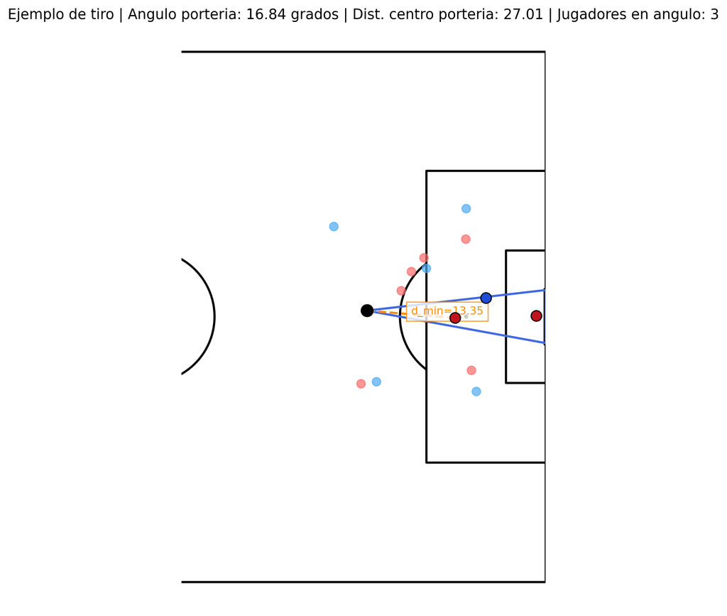

```python
def plot_ejemplo_angulo_rivales(df):
  # Selecciona un tiro con al menos un rival dentro del ángulo; si no hay, usa el primero disponible
  candidatos = df[df['num_rivales_angulo'] > 0]
  if candidatos.empty:
    if df.empty:
      print('No hay tiros disponibles para visualizar.')
      return
    row = df.iloc[0]
  else:
    row = candidatos.iloc[11]

  x_ball, y_ball = row['x'], row['y']
  angulo = row['angulo_porteria']
  distancia_centro = row['distancia_centro_porteria']
  distancia_min = row['distancia_rival_mas_cercano']

  rivales = row['rivales_en_angulo'] if isinstance(row['rivales_en_angulo'], list) else []
  companeros = row['companeros_en_angulo'] if isinstance(row['companeros_en_angulo'], list) else []

  rivales_x = [x for x, y, _ in rivales]
  rivales_y = [y for x, y, _ in rivales]
  companeros_x = [x for x, y, _ in companeros]
  companeros_y = [y for x, y, _ in companeros]

  rivales_block_x = [x for x, y, is_blocking in rivales if is_blocking]
  rivales_block_y = [y for x, y, is_blocking in rivales if is_blocking]
  companeros_block_x = [x for x, y, is_blocking in companeros if is_blocking]
  companeros_block_y = [y for x, y, is_blocking in companeros if is_blocking]

  pitch = Pitch(pitch_type='statsbomb', line_color='black', pitch_color='white')
  fig, ax = pitch.draw(figsize=(12, 8))

  # Mostrar solo la parte derecha del campo para dar efecto de zoom.
  ax.set_xlim(65, 120)

  # Triángulo visual del ángulo balón-portería
  ax.plot([x_ball, POSTE_1[0]], [y_ball, POSTE_1[1]], color='royalblue', linewidth=2, zorder=2)
  ax.plot([x_ball, POSTE_2[0]], [y_ball, POSTE_2[1]], color='royalblue', linewidth=2, zorder=2)
  ax.plot([POSTE_1[0], POSTE_2[0]], [POSTE_1[1], POSTE_2[1]], color='royalblue', linewidth=2, zorder=2)

  # Balón (punto de tiro)
  pitch.scatter([x_ball], [y_ball], ax=ax, color='black', s=120, marker='o', zorder=4)

  # Rivales en rojo (más intenso dentro del ángulo)
  if len(rivales_x) > 0:
    pitch.scatter(rivales_x, rivales_y, ax=ax, color='#ff6b6b', s=60, alpha=0.7, zorder=3)
  if len(rivales_block_x) > 0:
    pitch.scatter(rivales_block_x, rivales_block_y, ax=ax, color='#c1121f', edgecolors='black', s=95, zorder=4)

  # Companeros en azul (más intenso dentro del ángulo)
  if len(companeros_x) > 0:
    pitch.scatter(companeros_x, companeros_y, ax=ax, color='#4dabf7', s=60, alpha=0.7, zorder=3)
  if len(companeros_block_x) > 0:
    pitch.scatter(companeros_block_x, companeros_block_y, ax=ax, color='#1d4ed8', edgecolors='black', s=95, zorder=4)

  # Rival más cercano dentro del ángulo
  if len(rivales_block_x) > 0 and pd.notna(distancia_min):
    distancias = [((x - x_ball)**2 + (y - y_ball)**2)**0.5 for x, y in zip(rivales_block_x, rivales_block_y)]
    idx_min = int(np.argmin(distancias))
    x_near = rivales_block_x[idx_min]
    y_near = rivales_block_y[idx_min]

    ax.plot([x_ball, x_near], [y_ball, y_near], color='darkorange', linestyle='--', linewidth=2, zorder=3)
    ax.text(
      (x_ball + x_near) / 2,
      (y_ball + y_near) / 2,
      f"d_min={distancia_min:.2f}",
      color='darkorange',
      fontsize=10,
      bbox=dict(facecolor='white', edgecolor='darkorange', alpha=0.8),
    )

  titulo = (
    f"Ejemplo de tiro | Angulo porteria: {angulo:.2f} grados | "
    f"Dist. centro porteria: {distancia_centro:.2f} | "
    f"Jugadores en angulo: {int(row['num_jugadores_angulo'])}"
  )
  ax.set_title(titulo, fontsize=13)

  plt.show()


plot_ejemplo_angulo_rivales(shots_360_limpio)
```

# 5 Cálculo de métrica de Probabilidad de Gol

## 5.1 Cálculo de Probabilidad de Gol para el Lanzador

**Mostrar código**

```python
LAMBDA_METRICA = 0.08
ALPHA = 0.6

if shots_360_limpio.empty:
  raise ValueError('No hay tiros disponibles para calcular la probabilidad de gol.')

# Tomamos un solo disparo de ejemplo para toda esta sección.
tiro_ejemplo = shots_360_limpio.iloc[[1]].copy()


def calcular_probabilidad_gol(num_rivales_angulo, distancia_rival_mas_cercano, distancia_porteria):
  if pd.isna(distancia_porteria) or distancia_porteria <= 0:
    return np.nan

  # Si no hay defensor bloqueando, el término inverso se toma como 0.
  if pd.isna(distancia_rival_mas_cercano) or distancia_rival_mas_cercano <= 0:
    termino_defensor_cercano = 0.0
  else:
    termino_defensor_cercano = (1 - ALPHA) / distancia_rival_mas_cercano

  prob = np.exp(
    -LAMBDA_METRICA * distancia_porteria
    -ALPHA * num_rivales_angulo
    -termino_defensor_cercano
  )

  return float(np.clip(prob, 0.0, 1.0))


# Para el lanzador reutilizamos directamente las métricas ya calculadas arriba.
tiro_ejemplo['prob_gol_lanzador'] = tiro_ejemplo.apply(
  lambda row: calcular_probabilidad_gol(
    num_rivales_angulo=row['num_rivales_angulo'],
    distancia_rival_mas_cercano=row['distancia_rival_mas_cercano'],
    distancia_porteria=row['distancia_centro_porteria'],
  ),
  axis=1,
)


tabla_lanzador_prob_gol = tiro_ejemplo[[
  'id',
  'player_name',
  'num_rivales_angulo',
  'distancia_rival_mas_cercano',
  'distancia_centro_porteria',
  'prob_gol_lanzador',
]].rename(columns={
  'id': 'id_evento',
  'player_name': 'jugador',
  'num_rivales_angulo': 'num_rivales_angulo',
  'distancia_rival_mas_cercano': 'distancia_rival_mas_cercano',
  'distancia_centro_porteria': 'distancia_porteria',
  'prob_gol_lanzador': 'probabilidad_gol',
})

tabla_lanzador_prob_gol.style.format({
  'distancia_rival_mas_cercano': '{:.2f}',
  'distancia_porteria': '{:.2f}',
  'probabilidad_gol': '{:.3f}',
}).hide(axis='index')
```

| id_evento | jugador | num_rivales_angulo | distancia_rival_mas_cercano | distancia_porteria | probabilidad_gol |
| --- | --- | --- | --- | --- | --- |
| b2c3d59d-3bef-4f8a-ad86-26b69940c64e | Jonathan Tah | 1 | 7.43 | 9.59 | 0.241 |

## 5.2 Cálculo de Probabilidad de Gol para el resto de compañeros

**Mostrar código**

```python
def calcular_metricas_punto(x_ref, y_ref, lista_rivales):
  distancia_porteria = ((120 - x_ref)**2 + (40 - y_ref)**2)**0.5

  numerador = (120 - x_ref)**2 + (36 - y_ref) * (44 - y_ref)
  denominador = (
    ((120 - x_ref)**2 + (36 - y_ref)**2)**0.5
    *
    ((120 - x_ref)**2 + (44 - y_ref)**2)**0.5
  )
  angulo = np.degrees(np.arccos(np.clip(numerador / denominador, -1.0, 1.0))) if denominador != 0 else np.nan

  rivales_tripleta = []
  for rival in (lista_rivales if isinstance(lista_rivales, list) else []):
    x_rival = rival.get('x', np.nan)
    y_rival = rival.get('y', np.nan)

    if pd.isna(x_rival) or pd.isna(y_rival):
      continue

    is_blocking = punto_en_triangulo(x_rival, y_rival, x_ref, y_ref)
    rivales_tripleta.append((x_rival, y_rival, is_blocking))

  num_rivales = sum(1 for _, _, is_blocking in rivales_tripleta if is_blocking)
  distancias = [
    ((x_rival - x_ref)**2 + (y_rival - y_ref)**2)**0.5
    for x_rival, y_rival, is_blocking in rivales_tripleta
    if is_blocking
  ]
  distancia_rival_min = min(distancias) if distancias else np.nan
  prob = calcular_probabilidad_gol(num_rivales, distancia_rival_min, distancia_porteria)

  return {
    'angulo_porteria_companero': angulo,
    'num_rivales_angulo_companero': num_rivales,
    'distancia_centro_porteria_companero': distancia_porteria,
    'distancia_rival_mas_cercano_companero': distancia_rival_min,
    'prob_gol_companero': prob,
  }


def calcular_metricas_companeros(row):
  lista_companeros = row['posiciones_compañeros'] if isinstance(row['posiciones_compañeros'], list) else []
  lista_rivales = row['posiciones_rivales'] if isinstance(row['posiciones_rivales'], list) else []
  resultados = []

  for idx, comp in enumerate(lista_companeros, start=1):
    x_comp = comp.get('x', np.nan)
    y_comp = comp.get('y', np.nan)

    if pd.isna(x_comp) or pd.isna(y_comp):
      continue

    metricas = calcular_metricas_punto(x_comp, y_comp, lista_rivales)
    metricas['id_companero_frame'] = idx
    metricas['x_companero'] = x_comp
    metricas['y_companero'] = y_comp
    resultados.append(metricas)

  return resultados


tiro_ejemplo['metricas_companeros'] = tiro_ejemplo.apply(calcular_metricas_companeros, axis=1)

tiro_ejemplo[['metricas_companeros']].head()

companeros_detalle = []
for _, row in tiro_ejemplo.iterrows():
  id_evento = row.get('id', np.nan)
  jugador_lanzador = row.get('player_name', '')

  companeros_detalle.append({
    'id_evento': id_evento,
    'jugador': jugador_lanzador,
    'tipo_jugador': 'Lanzador',
    'id_companero': 0,
    'x_companero': row.get('x', np.nan),
    'y_companero': row.get('y', np.nan),
    'angulo_porteria': row.get('angulo_porteria', np.nan),
    'num_rivales_angulo': row.get('num_rivales_angulo', np.nan),
    'distancia_rival_mas_cercano': row.get('distancia_rival_mas_cercano', np.nan),
    'distancia_porteria': row.get('distancia_centro_porteria', np.nan),
    'probabilidad_gol': row.get('prob_gol_lanzador', np.nan),
    'es_lanzador': True,
  })

  for metricas_companero in (row.get('metricas_companeros', []) if isinstance(row.get('metricas_companeros', []), list) else []):
    companeros_detalle.append({
      'id_evento': id_evento,
      'jugador': f"Companero {metricas_companero.get('id_companero_frame', '')}",
      'tipo_jugador': 'Compañero visible',
      'id_companero': metricas_companero.get('id_companero_frame', np.nan),
      'x_companero': metricas_companero.get('x_companero', np.nan),
      'y_companero': metricas_companero.get('y_companero', np.nan),
      'angulo_porteria': metricas_companero.get('angulo_porteria_companero', np.nan),
      'num_rivales_angulo': metricas_companero.get('num_rivales_angulo_companero', np.nan),
      'distancia_rival_mas_cercano': metricas_companero.get('distancia_rival_mas_cercano_companero', np.nan),
      'distancia_porteria': metricas_companero.get('distancia_centro_porteria_companero', np.nan),
      'probabilidad_gol': metricas_companero.get('prob_gol_companero', np.nan),
      'es_lanzador': False,
    })

companeros_tabla = pd.DataFrame(companeros_detalle)


def resaltar_lanzador(row):
  if bool(row.get('es_lanzador', False)):
    return ['background-color: #1f2937; color: white;'] * len(row)
  return [''] * len(row)


companeros_tabla.style.apply(resaltar_lanzador, axis=1).format({
  'x_companero': '{:.2f}',
  'y_companero': '{:.2f}',
  'angulo_porteria': '{:.2f}',
  'num_rivales_angulo': '{:.0f}',
  'distancia_rival_mas_cercano': '{:.2f}',
  'distancia_porteria': '{:.2f}',
  'probabilidad_gol': '{:.3f}',
}).hide(axis='index')
```

| id_evento | jugador | tipo_jugador | id_companero | x_companero | y_companero | angulo_porteria | num_rivales_angulo | distancia_rival_mas_cercano | distancia_porteria | probabilidad_gol | es_lanzador |
| --- | --- | --- | --- | --- | --- | --- | --- | --- | --- | --- | --- |
| b2c3d59d-3bef-4f8a-ad86-26b69940c64e | Jonathan Tah | Lanzador | 0 | 113.90 | 47.40 | 32.72 | 1 | 7.43 | 9.59 | 0.241 | True |
| b2c3d59d-3bef-4f8a-ad86-26b69940c64e | Companero 1 | Compañero visible | 1 | 117.10 | 37.70 | 95.66 | 0 | nan | 3.70 | 0.744 | False |
| b2c3d59d-3bef-4f8a-ad86-26b69940c64e | Companero 2 | Compañero visible | 2 | 116.00 | 5.30 | 1.52 | 0 | nan | 34.93 | 0.061 | False |
| b2c3d59d-3bef-4f8a-ad86-26b69940c64e | Companero 3 | Compañero visible | 3 | 112.00 | 39.50 | 52.99 | 3 | 1.10 | 8.02 | 0.061 | False |
| b2c3d59d-3bef-4f8a-ad86-26b69940c64e | Companero 4 | Compañero visible | 4 | 115.50 | 40.50 | 82.87 | 1 | 3.68 | 4.53 | 0.343 | False |
| b2c3d59d-3bef-4f8a-ad86-26b69940c64e | Companero 5 | Compañero visible | 5 | 115.70 | 35.10 | 52.39 | 0 | nan | 6.52 | 0.594 | False |
| b2c3d59d-3bef-4f8a-ad86-26b69940c64e | Companero 6 | Compañero visible | 6 | 111.90 | 46.20 | 36.35 | 2 | 1.56 | 10.20 | 0.103 | False |
| b2c3d59d-3bef-4f8a-ad86-26b69940c64e | Companero 7 | Compañero visible | 7 | 95.90 | 49.40 | 16.45 | 4 | 17.63 | 25.87 | 0.011 | False |

## 5.3 Comparación entre la Probabilidad de Gol del Lanzador y la del resto de compañeros para evaluar la decisión de tiro

**Mostrar código**

```python
ranking_registros = []

for _, row in tiro_ejemplo.iterrows():
  id_evento = row.get('id', np.nan)
  jugador_lanzador = row.get('player_name', '')

  ranking_registros.append({
    'id_evento': id_evento,
    'jugador': jugador_lanzador,
    'tipo_jugador': 'Lanzador',
    'id_companero': 0,
    'x': row.get('x', np.nan),
    'y': row.get('y', np.nan),
    'angulo_porteria': row.get('angulo_porteria', np.nan),
    'num_rivales_angulo': row.get('num_rivales_angulo', np.nan),
    'distancia_rival_mas_cercano': row.get('distancia_rival_mas_cercano', np.nan),
    'distancia_porteria': row.get('distancia_centro_porteria', np.nan),
    'probabilidad_gol': row.get('prob_gol_lanzador', np.nan),
    'es_lanzador': True,
  })

  for metricas_companero in (row.get('metricas_companeros', []) if isinstance(row.get('metricas_companeros', []), list) else []):
    ranking_registros.append({
      'id_evento': id_evento,
      'jugador': f"Companero {metricas_companero.get('id_companero_frame', '')}",
      'tipo_jugador': 'Compañero visible',
      'id_companero': metricas_companero.get('id_companero_frame', np.nan),
      'x': metricas_companero.get('x_companero', np.nan),
      'y': metricas_companero.get('y_companero', np.nan),
      'angulo_porteria': metricas_companero.get('angulo_porteria_companero', np.nan),
      'num_rivales_angulo': metricas_companero.get('num_rivales_angulo_companero', np.nan),
      'distancia_rival_mas_cercano': metricas_companero.get('distancia_rival_mas_cercano_companero', np.nan),
      'distancia_porteria': metricas_companero.get('distancia_centro_porteria_companero', np.nan),
      'probabilidad_gol': metricas_companero.get('prob_gol_companero', np.nan),
      'es_lanzador': False,
    })

tabla_ranking = pd.DataFrame(ranking_registros)
tabla_ranking['ranking_probabilidad'] = tabla_ranking.groupby('id_evento')['probabilidad_gol'].rank(ascending=False, method='dense')
tabla_ranking['mejor_prob_evento'] = tabla_ranking.groupby('id_evento')['probabilidad_gol'].transform('max')
prob_lanzador_evento = tabla_ranking.loc[tabla_ranking['es_lanzador'], ['id_evento', 'probabilidad_gol']].set_index('id_evento')['probabilidad_gol']
tabla_ranking['prob_lanzador_evento'] = tabla_ranking['id_evento'].map(prob_lanzador_evento)
tabla_ranking['diferencia_vs_lanzador'] = tabla_ranking['probabilidad_gol'] - tabla_ranking['prob_lanzador_evento']
tabla_ranking['decision_optima_tiro'] = tabla_ranking['probabilidad_gol'] >= tabla_ranking['mejor_prob_evento']

tabla_ranking = tabla_ranking.sort_values(
  ['id_evento', 'ranking_probabilidad', 'probabilidad_gol'],
  ascending=[True, True, False],
)

def resaltar_lanzador_ranking(row):
  if bool(row.get('es_lanzador', False)):
    return ['background-color: #1f2937; color: white;'] * len(row)
  return [''] * len(row)


tabla_ranking.style.apply(resaltar_lanzador_ranking, axis=1).format({
  'angulo_porteria': '{:.2f}',
  'num_rivales_angulo': '{:.0f}',
  'distancia_rival_mas_cercano': '{:.2f}',
  'distancia_porteria': '{:.2f}',
  'probabilidad_gol': '{:.3f}',
  'prob_lanzador_evento': '{:.3f}',
  'ranking_probabilidad': '{:.0f}',
  'mejor_prob_evento': '{:.3f}',
  'diferencia_vs_lanzador': '{:.3f}',
}).hide(axis='index')
```

| id_evento | jugador | tipo_jugador | id_companero | x | y | angulo_porteria | num_rivales_angulo | distancia_rival_mas_cercano | distancia_porteria | probabilidad_gol | es_lanzador | ranking_probabilidad | mejor_prob_evento | prob_lanzador_evento | diferencia_vs_lanzador | decision_optima_tiro |
| --- | --- | --- | --- | --- | --- | --- | --- | --- | --- | --- | --- | --- | --- | --- | --- | --- |
| b2c3d59d-3bef-4f8a-ad86-26b69940c64e | Companero 1 | Compañero visible | 1 | 117.100000 | 37.700000 | 95.66 | 0 | nan | 3.70 | 0.744 | False | 1 | 0.744 | 0.241 | 0.502 | True |
| b2c3d59d-3bef-4f8a-ad86-26b69940c64e | Companero 5 | Compañero visible | 5 | 115.700000 | 35.100000 | 52.39 | 0 | nan | 6.52 | 0.594 | False | 2 | 0.744 | 0.241 | 0.352 | False |
| b2c3d59d-3bef-4f8a-ad86-26b69940c64e | Companero 4 | Compañero visible | 4 | 115.500000 | 40.500000 | 82.87 | 1 | 3.68 | 4.53 | 0.343 | False | 3 | 0.744 | 0.241 | 0.101 | False |
| b2c3d59d-3bef-4f8a-ad86-26b69940c64e | Jonathan Tah | Lanzador | 0 | 113.900000 | 47.400000 | 32.72 | 1 | 7.43 | 9.59 | 0.241 | True | 4 | 0.744 | 0.241 | 0.000 | False |
| b2c3d59d-3bef-4f8a-ad86-26b69940c64e | Companero 6 | Compañero visible | 6 | 111.900000 | 46.200000 | 36.35 | 2 | 1.56 | 10.20 | 0.103 | False | 5 | 0.744 | 0.241 | -0.138 | False |
| b2c3d59d-3bef-4f8a-ad86-26b69940c64e | Companero 2 | Compañero visible | 2 | 116.000000 | 5.300000 | 1.52 | 0 | nan | 34.93 | 0.061 | False | 6 | 0.744 | 0.241 | -0.180 | False |
| b2c3d59d-3bef-4f8a-ad86-26b69940c64e | Companero 3 | Compañero visible | 3 | 112.000000 | 39.500000 | 52.99 | 3 | 1.10 | 8.02 | 0.061 | False | 7 | 0.744 | 0.241 | -0.181 | False |
| b2c3d59d-3bef-4f8a-ad86-26b69940c64e | Companero 7 | Compañero visible | 7 | 95.900000 | 49.400000 | 16.45 | 4 | 17.63 | 25.87 | 0.011 | False | 8 | 0.744 | 0.241 | -0.230 | False |

## 5.4 Grid de campogramas por jugador en el tiro de ejemplo

**Mostrar código**

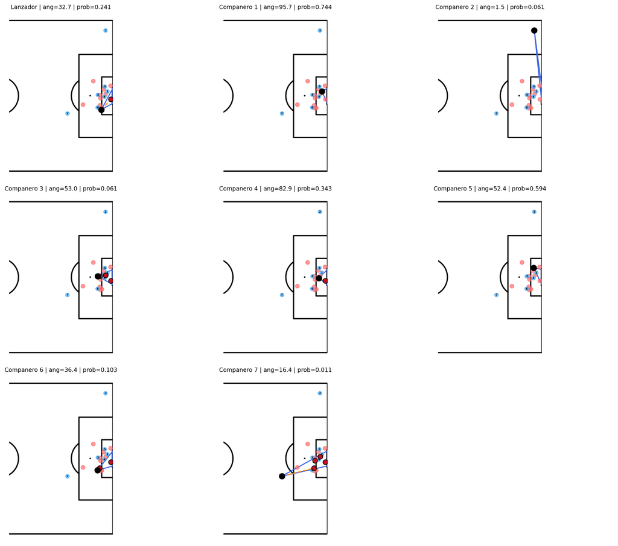

```python
def plot_grid_jugadores_tiro(row, ncols=3):
  companeros_frame = row['posiciones_compañeros'] if isinstance(row['posiciones_compañeros'], list) else []
  rivales_frame = row['posiciones_rivales'] if isinstance(row['posiciones_rivales'], list) else []

  # Candidatos: lanzador real (id frame 0) + cada compañero visible (id frame 1..N)
  candidatos = [{'id_frame': 0, 'x': row['x'], 'y': row['y'], 'es_lanzador': True}]
  for idx, comp in enumerate(companeros_frame, start=1):
    x_comp = comp.get('x', np.nan)
    y_comp = comp.get('y', np.nan)
    if pd.isna(x_comp) or pd.isna(y_comp):
      continue
    candidatos.append({'id_frame': idx, 'x': x_comp, 'y': y_comp, 'es_lanzador': False})

  n = len(candidatos)
  nrows = int(np.ceil(n / ncols))
  fig, axes = plt.subplots(nrows=nrows, ncols=ncols, figsize=(ncols * 5.0, nrows * 4.0))
  axes = np.array(axes).reshape(-1)
  pitch = Pitch(pitch_type='statsbomb', line_color='black', pitch_color='white')

  # Posiciones válidas para dibujar jugadores del frame en todos los subplots
  rivales_xy = [
    (r.get('x', np.nan), r.get('y', np.nan))
    for r in rivales_frame
    if not pd.isna(r.get('x', np.nan)) and not pd.isna(r.get('y', np.nan))
  ]
  companeros_xy = [
    (c.get('x', np.nan), c.get('y', np.nan))
    for c in companeros_frame
    if not pd.isna(c.get('x', np.nan)) and not pd.isna(c.get('y', np.nan))
  ]

  for ax_idx, ax in enumerate(axes):
    if ax_idx >= n:
      ax.axis('off')
      continue

    cand = candidatos[ax_idx]
    x_ref, y_ref = cand['x'], cand['y']

    metricas = calcular_metricas_punto(x_ref, y_ref, rivales_frame)
    angulo = metricas['angulo_porteria_companero']
    prob = metricas['prob_gol_companero']
    d_min = metricas['distancia_rival_mas_cercano_companero']

    # Rivales bloqueando desde la perspectiva del candidato actual
    rivales_tripleta = []
    for rival in rivales_frame:
      x_rival = rival.get('x', np.nan)
      y_rival = rival.get('y', np.nan)
      if pd.isna(x_rival) or pd.isna(y_rival):
        continue
      is_blocking = punto_en_triangulo(x_rival, y_rival, x_ref, y_ref)
      rivales_tripleta.append((x_rival, y_rival, is_blocking))

    rivales_block_x = [x for x, y, b in rivales_tripleta if b]
    rivales_block_y = [y for x, y, b in rivales_tripleta if b]

    pitch.draw(ax=ax)
    ax.set_xlim(65, 120)

    # Misma representación geométrica que la gráfica del lanzador
    ax.plot([x_ref, POSTE_1[0]], [y_ref, POSTE_1[1]], color='royalblue', linewidth=1.6, zorder=2)
    ax.plot([x_ref, POSTE_2[0]], [y_ref, POSTE_2[1]], color='royalblue', linewidth=1.6, zorder=2)
    ax.plot([POSTE_1[0], POSTE_2[0]], [POSTE_1[1], POSTE_2[1]], color='royalblue', linewidth=1.6, zorder=2)

    if len(rivales_xy) > 0:
      pitch.scatter([x for x, _ in rivales_xy], [y for _, y in rivales_xy], ax=ax, color='#ff6b6b', s=38, alpha=0.7, zorder=3)
    if len(rivales_block_x) > 0:
      pitch.scatter(rivales_block_x, rivales_block_y, ax=ax, color='#c1121f', edgecolors='black', s=58, zorder=4)

    if len(companeros_xy) > 0:
      pitch.scatter([x for x, _ in companeros_xy], [y for _, y in companeros_xy], ax=ax, color='#4dabf7', s=34, alpha=0.75, zorder=3)

    # Candidato actual en negro
    pitch.scatter([x_ref], [y_ref], ax=ax, color='black', s=78, marker='o', zorder=5)
    ax.text(x_ref, y_ref, str(cand['id_frame']), color='black', fontsize=5, ha='center', va='center', zorder=6, fontweight='bold')

    # IDs de compañeros del frame
    for idx_comp, (x_comp, y_comp) in enumerate(companeros_xy, start=1):
      ax.text(x_comp, y_comp, str(idx_comp), color='black', fontsize=4.3, ha='center', va='center', zorder=6, fontweight='bold')

    # Distancia al rival más cercano bloqueando
    if len(rivales_block_x) > 0 and pd.notna(d_min):
      distancias = [((x - x_ref)**2 + (y - y_ref)**2)**0.5 for x, y in zip(rivales_block_x, rivales_block_y)]
      idx_min = int(np.argmin(distancias))
      x_near = rivales_block_x[idx_min]
      y_near = rivales_block_y[idx_min]
      ax.plot([x_ref, x_near], [y_ref, y_near], color='darkorange', linestyle='--', linewidth=1.6, zorder=3)

    tipo = 'Lanzador' if cand['es_lanzador'] else f"Companero {cand['id_frame']}"
    ax.set_title(f"{tipo} | ang={angulo:.1f} | prob={prob:.3f}", fontsize=9)

  plt.tight_layout()
  plt.show()


plot_grid_jugadores_tiro(tiro_ejemplo.iloc[0], ncols=3)
```